# Applied Machine Learning and Predictive Modelling 1 - Group Work

Ana Nicolasa Caduff, Yarkin Göcmen, Andy Gubser and Alexandra Strohmeier (Group ID 4)

# 1 Preparation

## 1.1 Load libraries and read data

```r
# install and load packages
list.of.packages <- c("plyr", "ggplot2", "tidyverse", "dplyr", "e1071", "randomForest", "tree", "caret", "neuralnet")
install.and.load.package <- function(package){
  if (!require(package, character.only = TRUE)) install.packages(package, character.only=TRUE)
  library(package, character.only = TRUE, warn.conflicts = FALSE)
}
lapply(list.of.packages, install.and.load.package)
# read data
read_csv_filename <- function(filename){
    d <- read.csv(filename)

    d[,"fuel"] <- substring(filename,
                gregexpr("_", filename)[[1]][1] +1,
                gregexpr("_", filename)[[1]][2] -1
                )

    d[,"provider"] <- substring(filename,
                gregexpr("/", filename)[[1]][2] +1,
                gregexpr("_", filename)[[1]][1] -1
                )

    d[,"year"] <- as.numeric(substring(filename,
                  gregexpr("2", filename)[[1]][1],
                  gregexpr(".csv", filename)[[1]][1] -1
                  ))
    d
}
```

```r
mydir = "./dutch-energy/"
myfiles = list.files(path=mydir, pattern="*.csv", recursive=TRUE, full.names=TRUE)

myfiles
```

```
##  [1] "./dutch-energy//Electricity/enexis_electricity_01012010.csv"
##  [2] "./dutch-energy//Electricity/enexis_electricity_01012011.csv"
##  [3] "./dutch-energy//Electricity/enexis_electricity_01012012.csv"
##  [4] "./dutch-energy//Electricity/enexis_electricity_01012013.csv"
##  [5] "./dutch-energy//Electricity/enexis_electricity_01012014.csv"
##  [6] "./dutch-energy//Electricity/enexis_electricity_01012015.csv"
##  [7] "./dutch-energy//Electricity/enexis_electricity_01012016.csv"
##  [8] "./dutch-energy//Electricity/enexis_electricity_01012017.csv"
##  [9] "./dutch-energy//Electricity/enexis_electricity_01012018.csv"
## [10] "./dutch-energy//Electricity/enexis_electricity_01012019.csv"
## [11] "./dutch-energy//Electricity/liander_electricity_01012009.csv"
## [12] "./dutch-energy//Electricity/liander_electricity_01012010.csv"
## [13] "./dutch-energy//Electricity/liander_electricity_01012011.csv"
## [14] "./dutch-energy//Electricity/liander_electricity_01012012.csv"
## [15] "./dutch-energy//Electricity/liander_electricity_01012013.csv"
```

[output cut: 49 more lines]

```r
length(myfiles)
```

```
## [1] 64
```

```r
df <- ldply(myfiles, read_csv_filename)
```

The user function extracts fuel (energy source), provider and year substrings from the filenames and reads csv files into R. The function is executed over all 64 files within the dutch energy folder.

## 1.2 Describe Data

```r
head(df)
```

|  | net_manager | purchase_area | street | zipcode_from | zipcode_to | city | delivery_perc | num_connections | perc_of_active_connections | type_conn_perc | type_of_connection | annual_consume | annual_consume_lowtarif_perc | smartmeter_perc | fuel | provider | year |
| --- | --- | --- | --- | --- | --- | --- | --- | --- | --- | --- | --- | --- | --- | --- | --- | --- | --- |
| 1 | Enexis B.V. | ENEXIS | Sasdijk | 4251AB | 4251AB | WERKENDAM | 100 | 16 | 100 | NA | NA | 4282 | 25 | 0 | electricity | /Electricity/enexis | 2010 |
| 2 | Enexis B.V. | ENEXIS | Sasdijk | 4251AC | 4251AC | WERKENDAM | 100 | 11 | 100 | NA | NA | 5113 | 10 | 0 | electricity | /Electricity/enexis | 2010 |
| 3 | Enexis B.V. | ENEXIS | Sasdijk | 4251AD | 4251AD | WERKENDAM | 100 | 30 | 100 | NA | NA | 4809 | 34 | 0 | electricity | /Electricity/enexis | 2010 |
| 4 | Enexis B.V. | ENEXIS | Nieuweweg | 4251AE | 4251AG | WERKENDAM | 100 | 21 | 100 | NA | NA | 5015 | 44 | 0 | electricity | /Electricity/enexis | 2010 |
| 5 | Enexis B.V. | ENEXIS | Koppenhof | 4251AH | 4251AH | WERKENDAM | 100 | 12 | 100 | NA | NA | 3074 | 22 | 0 | electricity | /Electricity/enexis | 2010 |
| 6 | Enexis B.V. | ENEXIS | Plein | 4251AJ | 4251AJ | WERKENDAM | 100 | 26 | 100 | NA | NA | 5480 | 26 | 0 | electricity | /Electricity/enexis | 2010 |

```r
str(df)
```

```
## 'data.frame':    6651550 obs. of  17 variables:
##  $ net_manager                 : chr  "Enexis B.V." "Enexis B.V." "Enexis B.V." "Enexis B.V." ...
##  $ purchase_area               : chr  "ENEXIS" "ENEXIS" "ENEXIS" "ENEXIS" ...
##  $ street                      : Factor w/ 112135 levels "'s-Gravenhagestraat",..: 27483 27483 27483 21785 16925 24940 37957 37620 29099 23302 ...
##  $ zipcode_from                : Factor w/ 362359 levels "4251AB","4251AC",..: 1 2 3 4 5 6 7 8 9 10 ...
##  $ zipcode_to                  : Factor w/ 355587 levels "4251AB","4251AC",..: 1 2 3 4 5 6 7 8 9 10 ...
##  $ city                        : Factor w/ 2501 levels "'S-HEERENBROEK",..: 962 962 962 962 962 962 962 962 962 962 ...
##  $ delivery_perc               : num  100 100 100 100 100 100 100 100 100 100 ...
##  $ num_connections             : num  16 11 30 21 12 26 24 32 21 11 ...
##  $ perc_of_active_connections  : num  100 100 100 100 100 100 100 100 100 100 ...
##  $ type_conn_perc              : num  NA NA NA NA NA NA NA NA NA NA ...
##  $ type_of_connection          : int  NA NA NA NA NA NA NA NA NA NA ...
##  $ annual_consume              : num  4282 5113 4809 5015 3074 ...
##  $ annual_consume_lowtarif_perc: num  25 10 34 44 22 26 34 44 49 19 ...
##  $ smartmeter_perc             : num  0 0 0 0 0 0 0 0 0 0 ...
##  $ fuel                        : chr  "electricity" "electricity" "electricity" "electricity" ...
##  $ provider                    : chr  "/Electricity/enexis" "/Electricity/enexis" "/Electricity/enexis" "/Electricity/enexis" ...
##  $ year                        : num  2010 2010 2010 2010 2010 2010 2010 2010 2010 2010 ...
```

```r
dim(df)
```

```
## [1] 6651550      17
```

```r
names(df)
```

```
##  [1] "net_manager"                  "purchase_area"
##  [3] "street"                       "zipcode_from"
##  [5] "zipcode_to"                   "city"
##  [7] "delivery_perc"                "num_connections"
##  [9] "perc_of_active_connections"   "type_conn_perc"
## [11] "type_of_connection"           "annual_consume"
## [13] "annual_consume_lowtarif_perc" "smartmeter_perc"
## [15] "fuel"                         "provider"
## [17] "year"
```

```r
nrow(df %>% filter(fuel=='gas'))
```

```
## [1] 3085757
```

```r
nrow(df %>% filter(fuel=='electricity'))
```

```
## [1] 3565793
```

All datasets in folder Electricity and Gas have the same 14 column names. The datasets in folder Electricity have 3,565,793 observations, whereas the datasets in folder Gas have 3,085,757 observations.

# 2 Part 1

## 2.1 Explore relationship between smart meter pct and total consumption of electricity

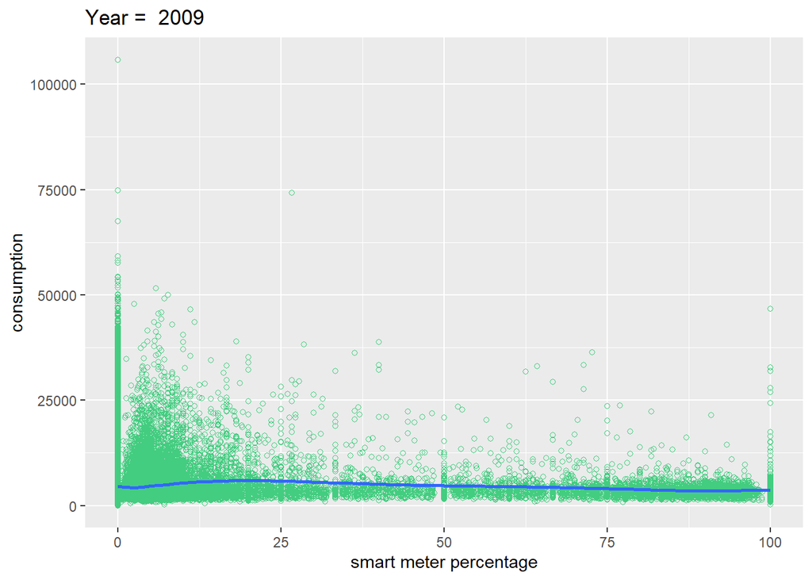

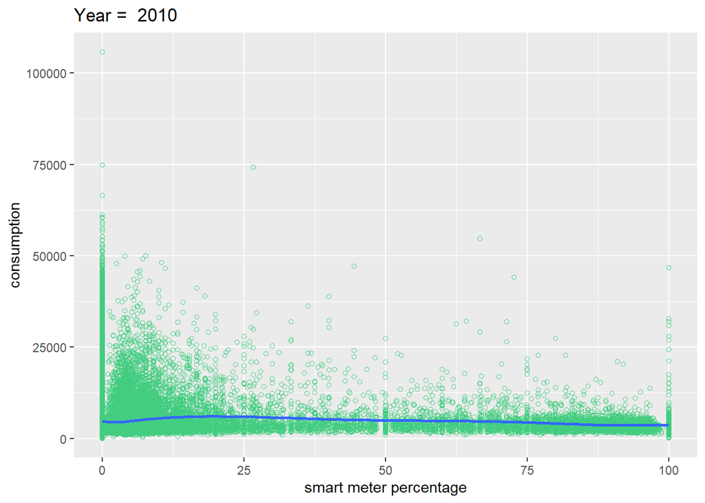

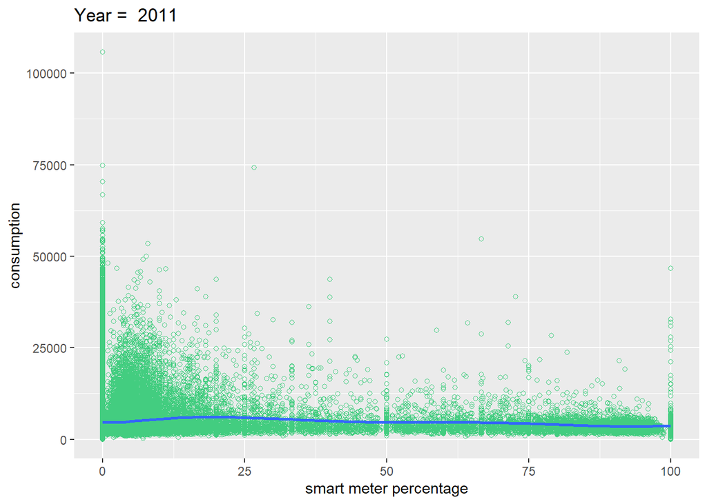

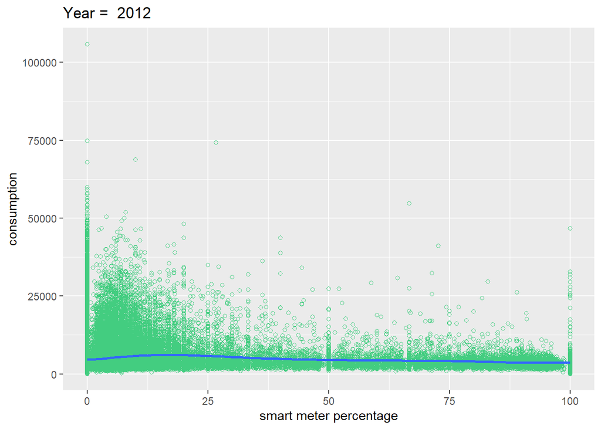

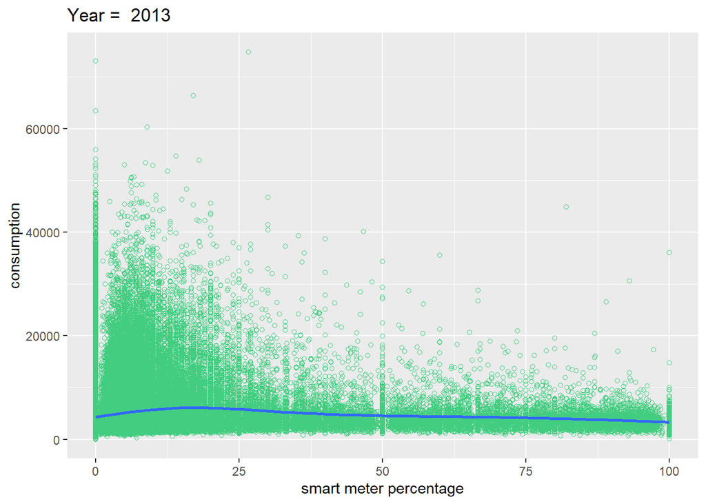

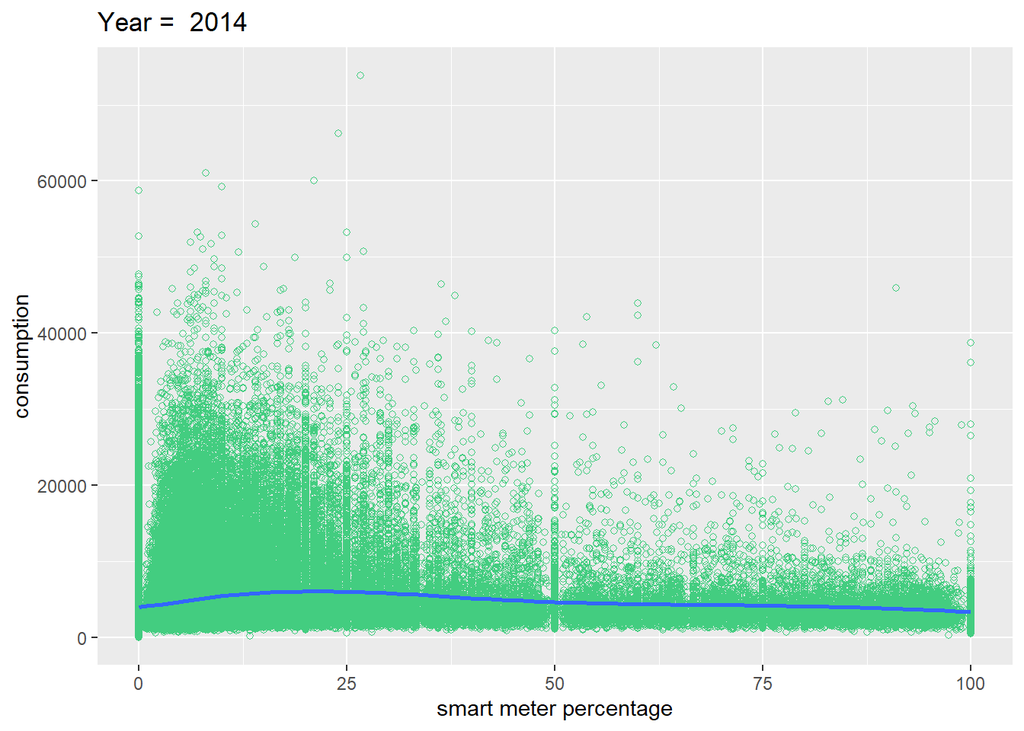

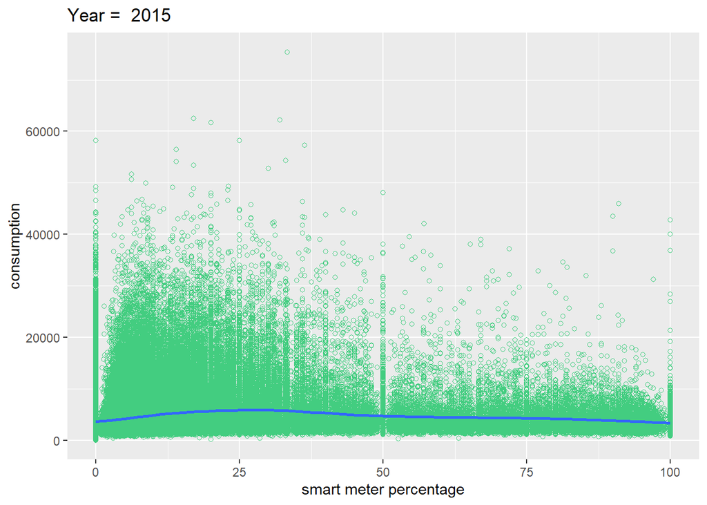

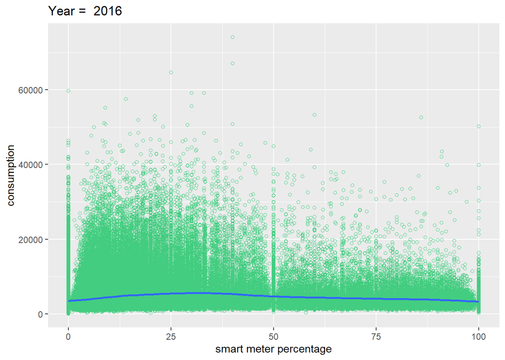

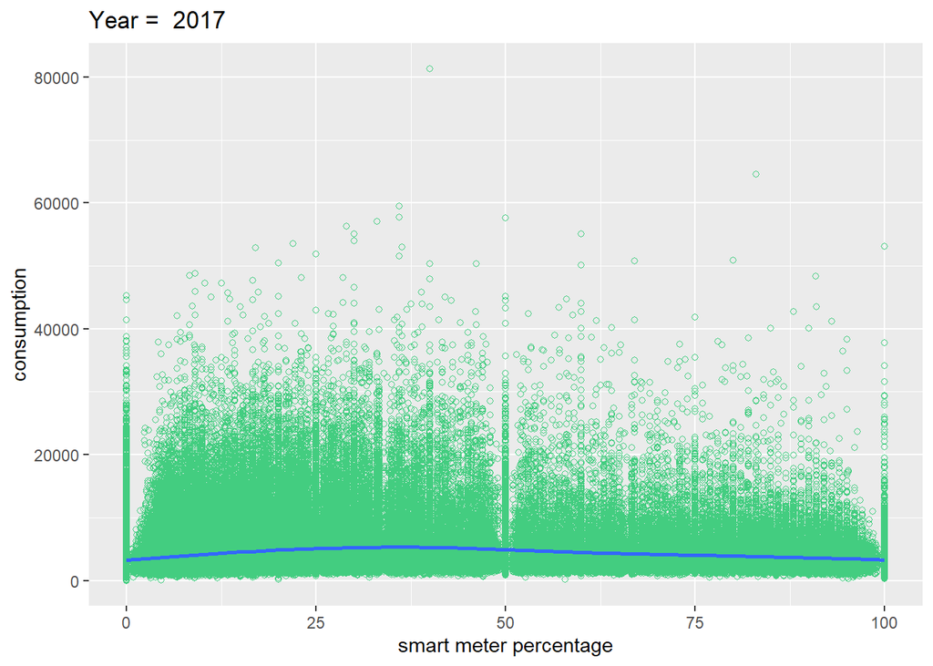

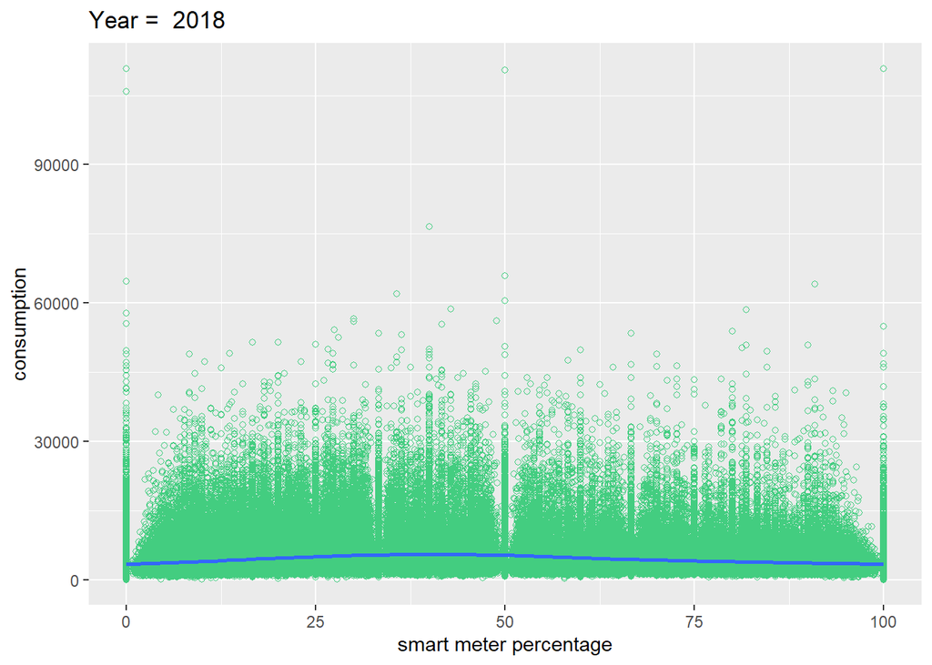

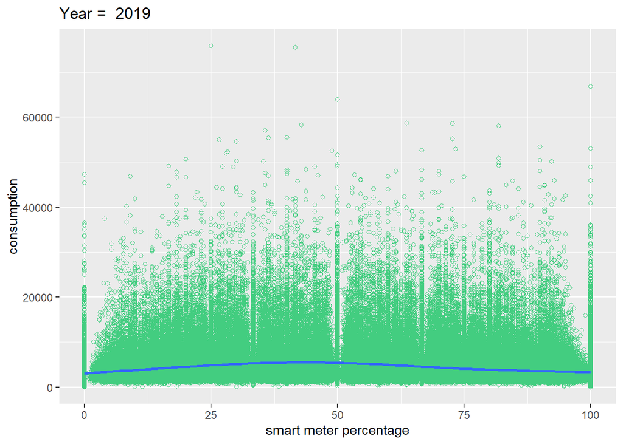

```r
for (j in seq(2009,2019,1)){
print(ggplot(data=df%>% filter(fuel=='electricity',year==j) , aes(x=smartmeter_perc, y=annual_consume)) + geom_point(shape=1,color='seagreen3') + labs(x='smart meter percentage',y='consumption',title = paste('Year = ',j ))+geom_smooth())
}
```

The variable electricity consumption is plotted against smart meter percentage for each year between 2009 to 2019. The blue line corresponds to the smoothed conditional mean.

There is an unclear relationship between smart meter percentages and electricity consumption. The smoothed mean is increasing for small smart meter percentages, but then it reaches a maximal electricity consumption level and decreases again. This can be observed for each year.

## 2.2 Explore relationship between ratio of low_tarif electricity consumption and total consumption electricity

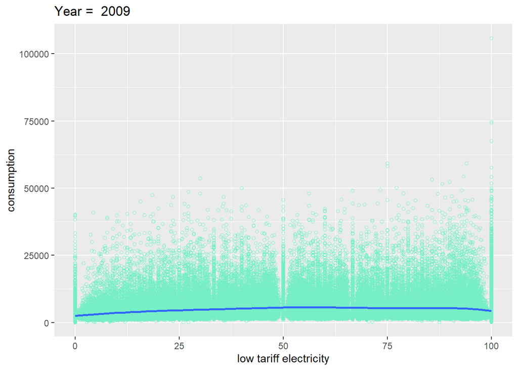

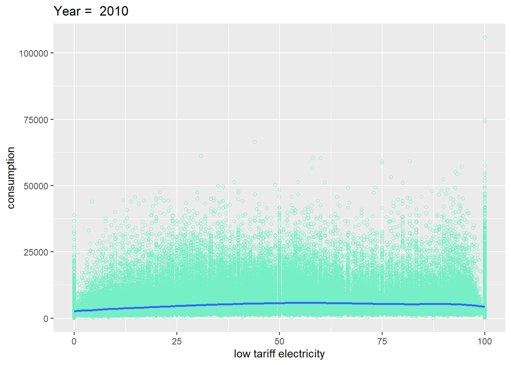

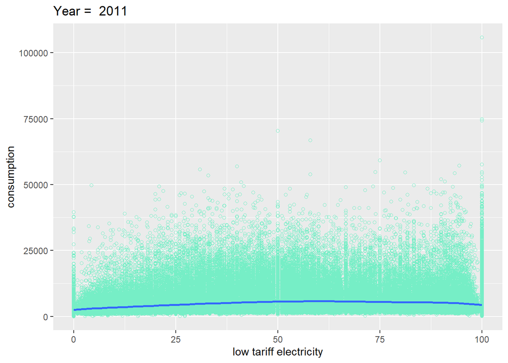

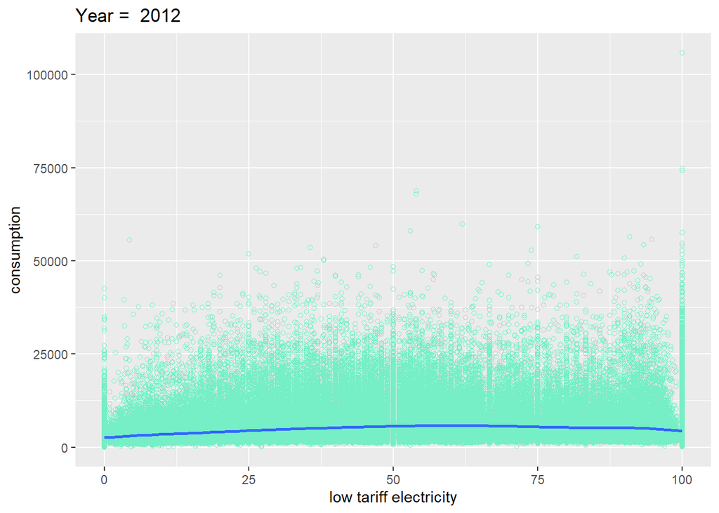

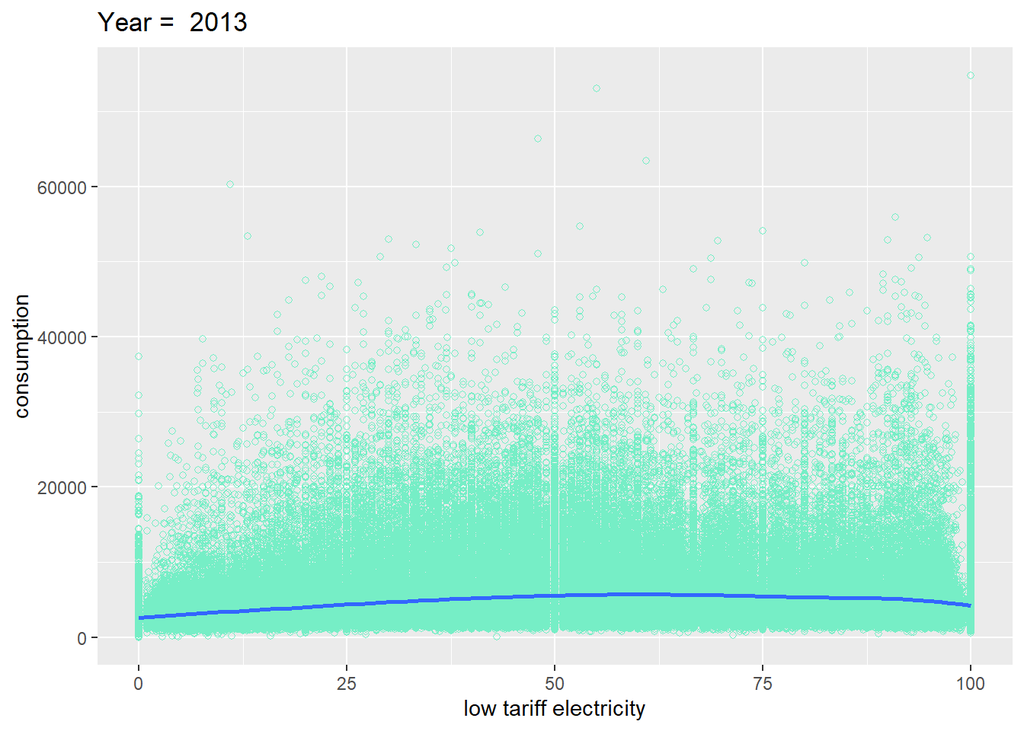

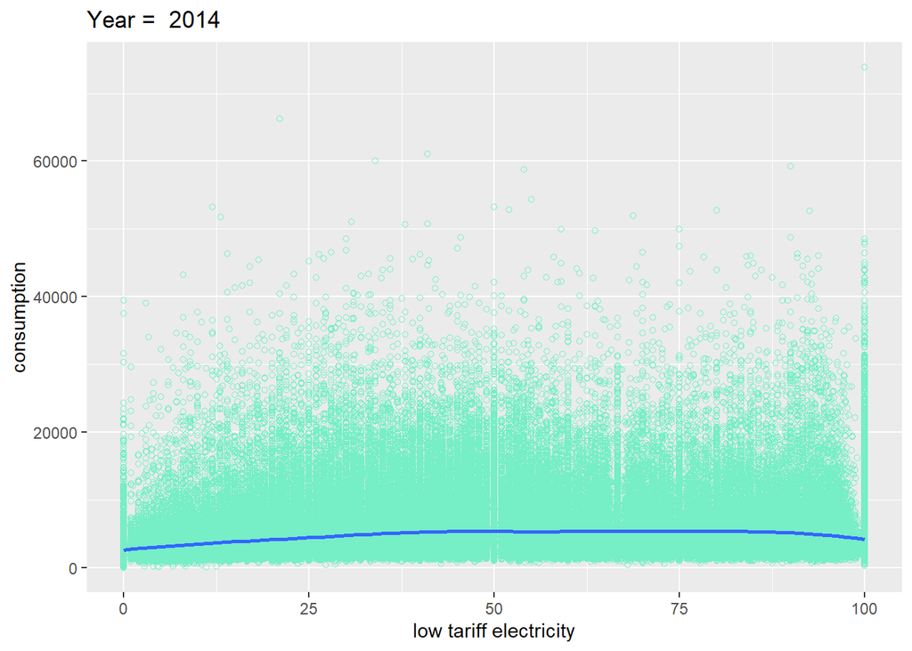

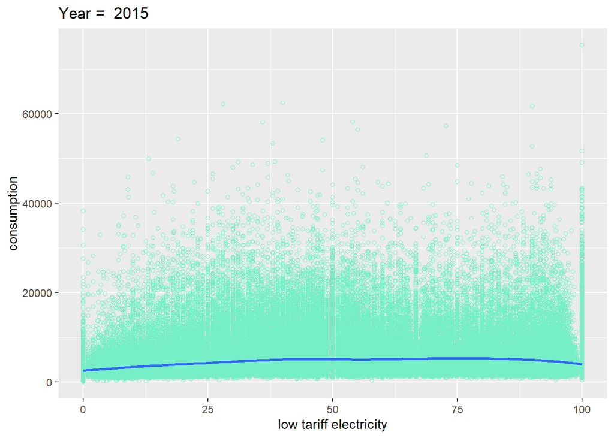

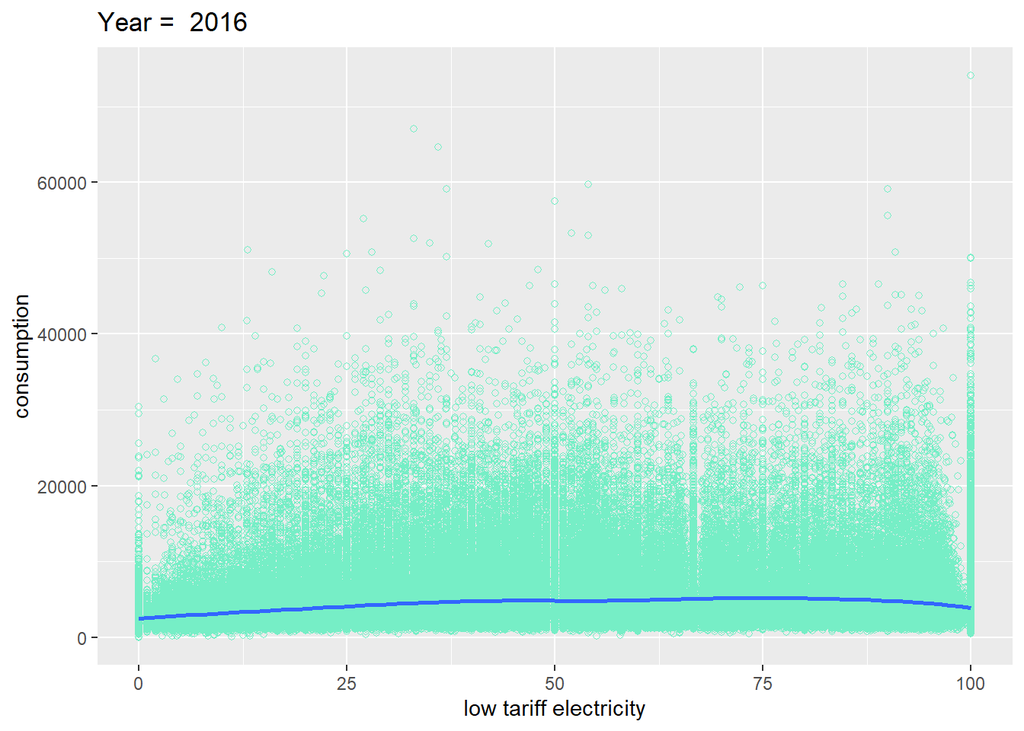

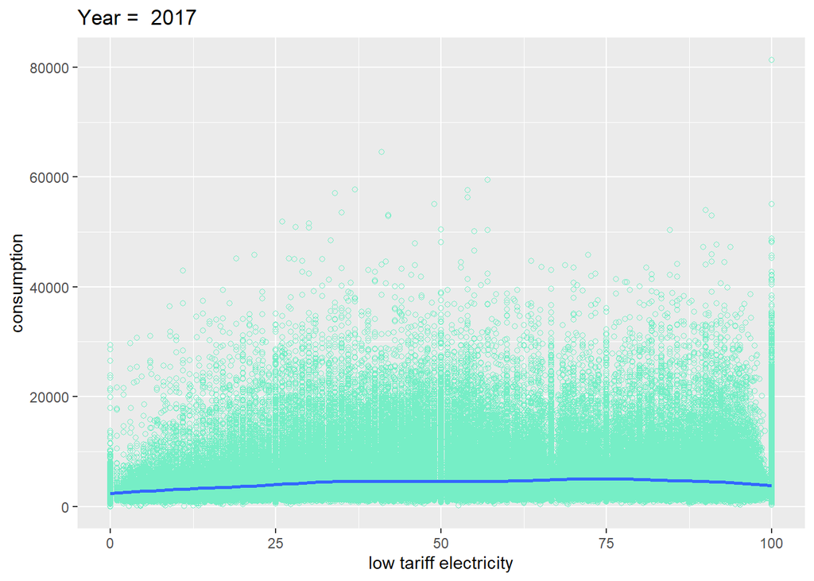

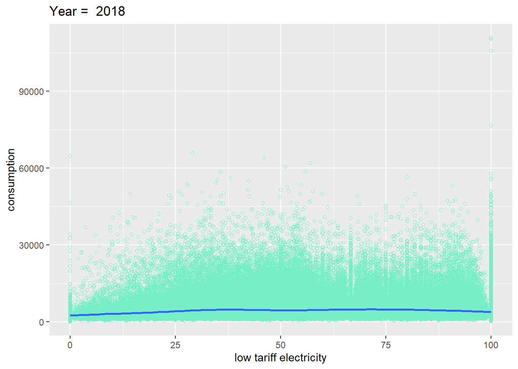

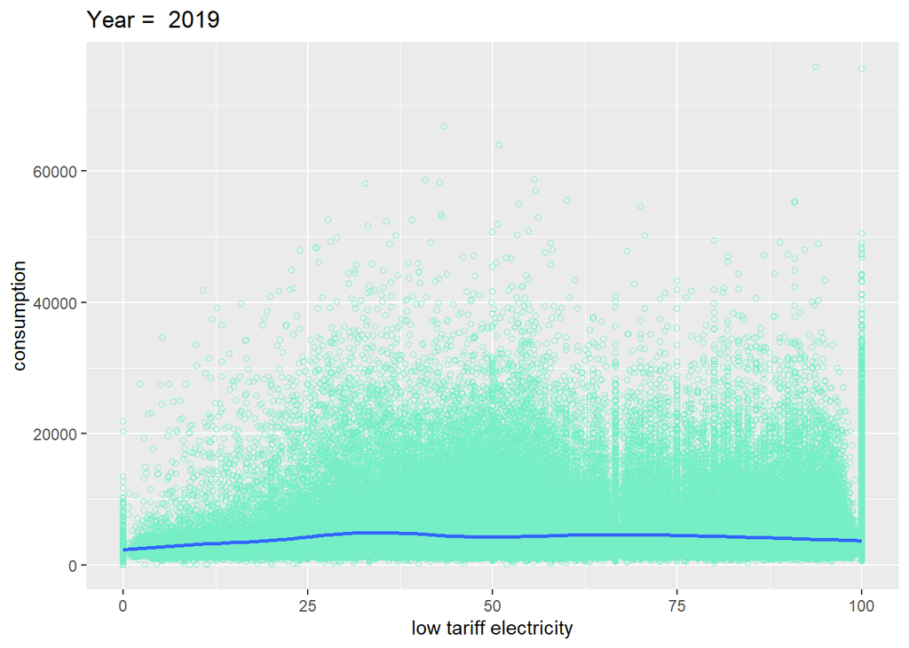

```r
for (j in seq(2009,2019,1)){
print(ggplot(data=df%>% filter(fuel=='electricity',year==j) , aes(x=annual_consume_lowtarif_perc, y=annual_consume)) +
    labs(x='low tariff electricity',y='consumption',title=paste('Year = ',j))+ geom_point(shape=1, color="aquamarine2") + geom_smooth())}
```